# Исследование структуры временных рядов в R (практика)

Заходякин Г.В., postlogist@gmail.com

# Введение

В этом блокноте разобран пример анализа регулярного временного ряда из базы данных ВШЭ Sophist с использованием метода классической декомпозиции (базовый R) и STL-декомпозиции (пакет `forecast`).

```r
library(tidyverse) # ggplot2 и трансформация данных
library(forecast) # анализ временных рядов и прогнозирование
library(sophisthse) # Загрузка временных рядов из базы Sophist
library(stringr)  # Работа с текстовыми строками
```

# Как загрузить данные из Sophist

Для автоматической загрузки данных из БД Sophist можно использовать пакет [`sophisthse`](https://CRAN.R-project.org/package=sophisthse), разработанный Борисом Демешевым. В дистрибутив для курса этот пакет включен. Если вы самостоятельно устанавливали R, то убедитесь в том, что у вас этот пакет установлен. Как обычно, пакет из CRAN можно установить командой `install.packages()`.

Главная функция пакета - `sophisthse()` - загружает многомерные временные ряды, т.е. таблицы. Чтобы загрузить временной ряд, надо знать название соответствующего показателя. Вы можете узнать имена показателей в самой базе данных - см. http://sophist.hse.ru/hse/nindex.shtml.

Например, открыв таблицу http://sophist.hse.ru/exes/tables/RTRD_M_I.htm, можно узнать, что показатель: `Оборот розничной торговли в текущих ценах` называется `RTRD_M`.

Другой способ - просмотр встроенного в пакет списка показателей (`series_info`)

```r
head(series_info, n = 10)
```

```
##          table      tsname freq     unit
## 1     POPNUM_Y    POPNUM_Y    1  тыс.чел
## 2     POPFER_Y    POPFER_Y    1 промилле
## 3     POPMOR_Y    POPMOR_Y    1 промилле
## 4     UNEMPL_Y    UNEMPL_Y    1  млн.чел
## 5     UNEMPL_Q    UNEMPL_Q    4  млн.чел
## 6     UNEMPL_M    UNEMPL_M   12  млн.чел
## 7  UNEMPL_Y_SH UNEMPL_Y_SH    1        %
## 8  UNEMPL_Q_SH UNEMPL_Q_SH    4        %
## 9  UNEMPL_M_SH UNEMPL_M_SH   12        %
## 10   EMPLDEC_Y   EMPLDEC_Y    1  тыс.чел
##                                                                  fullname
## 1                      Численность населения (на начало года)  (POPNUM_Y)
## 2                                     Коэффициент рождаемости  (POPFER_Y)
## 3                                      Коэффициент смертности  (POPMOR_Y)
```

[output cut: 40 more lines]

Заметим, что название показателя для загрузки содержится в столбце `tsname`, а расшифровка - в столбце `fullname`.

Можно искать показатель в таблице, используя поиск по шаблону строки (`stringr::str_detect()`). В простейшем случае шаблон - это искомая подстрока. Более сложные шаблоны (регулярные выражения) описаны в книге [R for data science](http://r4ds.had.co.nz/strings.html) - см. раздел 14.1.

```r
series_info %>%
  filter(str_detect(fullname, 'розн')) %>%
  select(fullname, tsname, unit)
```

```
##                                                                                                                                        fullname
## 1       G.Оптовая и розничная торговля; ремонт автотранспортных средств, мотоциклов, бытовых изделий и предметов личного пользования  (GVA_G_Y)
## 2  G.Оптовая и розничная торговля; ремонт автотранспортных средств, мотоциклов, бытовых изделий и предметов личного пользования  (GVA_G_Y_DIRI)
## 3                                                                                                           Оборот розничной торговли  (RTRD_Y)
## 4                                                                                    Индекс реального оборота розничной торговли  (RTRD_Q_DIRI)
## 5                                                      Индекс реального оборота розничной торговли, с поправкой на сезонность  (RTRD_Q_DIRI_SA)
## 6                                                                                           Оборот розничной торговли в текущих ценах  (RTRD_Q)
## 7                                                                                    Индекс реального оборота розничной торговли  (RTRD_M_DIRI)
## 8                                                      Индекс реального оборота розничной торговли, с поправкой на сезонность  (RTRD_M_DIRI_SA)
## 9                                                                                           Оборот розничной торговли в текущих ценах  (RTRD_M)
## 10                                                                                   Индекс реального оборота розничной торговли  (RTRD_Y_DIRI)
##            tsname                                  unit
## 1         GVA_G_Y текущие (основные) цены, млрд. рублей
## 2    GVA_G_Y_DIRI                              2002=100
## 3          RTRD_Y    текущие цены, млрд. (трлн.) рублей
## 4     RTRD_Q_DIRI                           1994.I =100
## 5  RTRD_Q_DIRI_SA                   1994.I(факт ) = 100
## 6          RTRD_Q                             млрд.руб.
## 7     RTRD_M_DIRI                            1994.1=100
## 8  RTRD_M_DIRI_SA                      1994.1(факт)=100
## 9          RTRD_M                             млрд.руб.
## 10    RTRD_Y_DIRI                              1994=100
```

При указании имени показателя загружается вся таблица, в которой он содержится.

```r
retail <- sophisthse('RTRD_M')
head(retail)
```

```
##          RTRD_M_DIRI RTRD_M_DIRI_SA RTRD_M
## Jan 1994       100.0          107.1     NA
## Feb 1994       100.0          108.2     NA
## Mar 1994       117.7          109.0     NA
## Apr 1994       107.6          109.4     NA
## May 1994       102.0          109.8     NA
## Jun 1994       106.6          110.7     NA
## attr(,"metadata")
## # A tibble: 3 x 7
##   tsname  unit   fullname      methodology     source     comment      freq
##   <chr>   <chr>  <chr>         <chr>           <chr>      <chr>       <dbl>
## 1 RTRD_M~ 1994.~ Индекс реаль~ Индекс физичес~ Федеральн~ Пересчет и~    12
## 2 RTRD_M~ 1994.~ Индекс реаль~ Сезонное сглаж~ Рассчитан~ -              12
## 3 RTRD_M  млрд.~ Оборот розни~ Оборот розничн~ Федеральн~ -              12
```

Посмотреть описание загруженных данных:

```r
sophisthse_metadata(retail)
```

```
## # A tibble: 3 x 7
##   tsname  unit   fullname      methodology     source     comment      freq
##   <chr>   <chr>  <chr>         <chr>           <chr>      <chr>       <dbl>
## 1 RTRD_M~ 1994.~ Индекс реаль~ Индекс физичес~ Федеральн~ Пересчет и~    12
## 2 RTRD_M~ 1994.~ Индекс реаль~ Сезонное сглаж~ Рассчитан~ -              12
## 3 RTRD_M  млрд.~ Оборот розни~ Оборот розничн~ Федеральн~ -              12
```

Полученный объект имеет тип многомерного временного ряда (`mts`) и матрицы (`matrix`).

```r
class(retail)
```

```
## [1] "mts"    "ts"     "matrix"
```

Извлечь нужный столбец можно по индексу. Рекомендуем использовать имена столбцов, а не номера, чтобы избежать ошибок при изменении числа столбцов в таблице.

```r
# Извлечение столбца
rtrd <- retail[, 'RTRD_M']

# Тип объекта для одномерного ряда
class(rtrd)
```

```
## [1] "ts"
```

```r
# Вывод значений
rtrd %>% head(36)
```

```
##       Jan  Feb  Mar  Apr  May  Jun  Jul  Aug  Sep  Oct  Nov  Dec
## 1994   NA   NA   NA   NA   NA   NA   NA   NA   NA   NA   NA   NA
## 1995 27.3 28.1 32.9 33.4 39.4 41.7 43.7 47.5 49.4 52.7 55.1 60.7
## 1996 57.5 53.3 57.1 58.6 58.2 58.9 60.1 61.2 62.5 63.1 64.0 72.6
```

Таблица даже с единственным столбцом имеет тип многомерного ряда, поэтому может потребоваться “извлечь” оттуда столбец по индексу, чтобы с ним могли работать функции для прогнозирования и визуализации.

В начале ряда есть пропущенные значения. Чтобы удалить их, отберем наблюдения начиная с января 1995 года

```r
rtrd <- rtrd %>%
  window(start = c(1995, 1))
```

# Анализ временного ряда

## Визуализация

Для построения графиков нам потребуются подписи для заголовка и осей. Их можно задать вручную, но можно и извлечь из метаданных ряда.

```r
# Метка и единица измерения
rtrd_info <- sophisthse_metadata(retail) %>%
  filter(tsname == 'RTRD_M') %>%
  select(fullname, unit)

rtrd_label <- rtrd_info$fullname
rtrd_unit <- rtrd_info$unit
```

Функции базовой графики R могут работать с временными рядами `ts` непосредственно. Для визуализации временного ряда средствами `ggplot2` необходимо использовать функцию `autoplot()` пакета `forecast`. В результате получается объект, с которым можно продолжить работу стандартными средствами `ggplot2`.

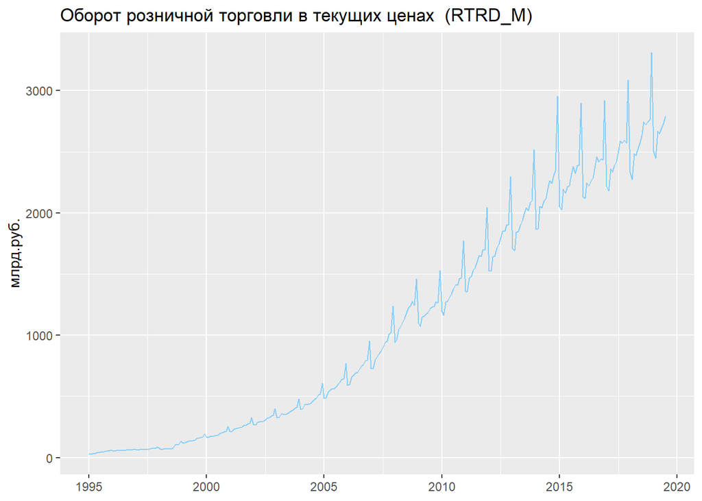

```r
autoplot(rtrd) +
  labs(y = rtrd_unit, x = NULL,
       title = rtrd_label) +
  geom_line(color = 'lightSkyblue')
```

Справку по использованию функции можно получить командой: `?autoplot.ts` или [онлайн](https://www.rdocumentation.org/packages/forecast/versions/8.1/topics/autolayer.mts).

## Классическая сезонная декомпозиция

Декомпозиция временного ряда позволяет выделить отдельные его компоненты - тренд, сезонность и нерегулярные изменения (остаток).

Форма графика временного ряда позволяет предположить наличие тренда и сезонных колебаний мультипликативного типа.

Вначале воспользуемся встроенной функцией R - `decompose()`, реализующей метод классической декомпозиции на основе скользящего среднего. Визуализировать результаты можно с помощью функции `autoplot()`

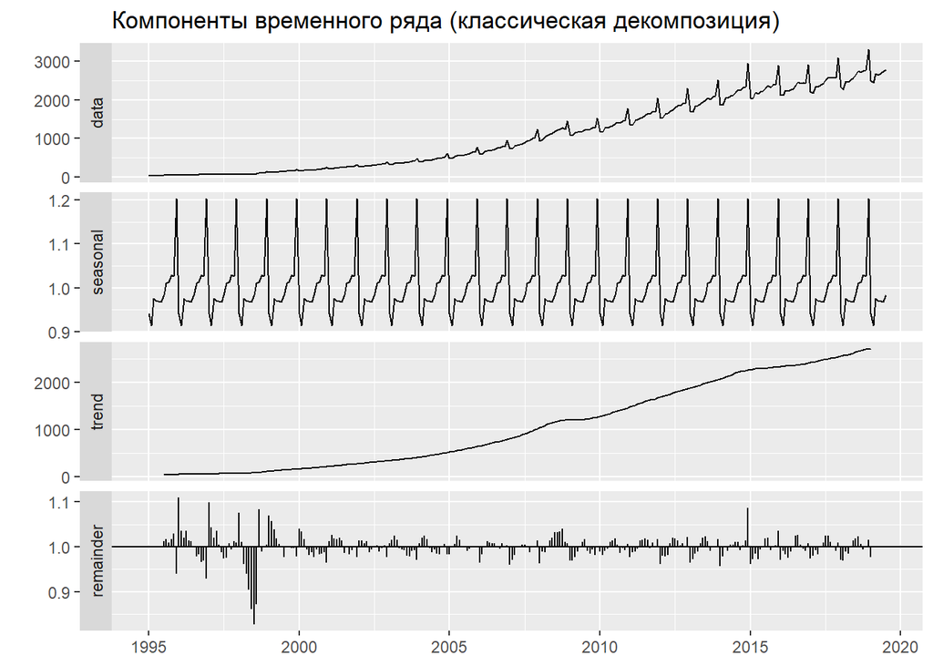

```r
rtrd_d <- rtrd %>%
  decompose(type = 'multiplicative')

autoplot(rtrd_d) +
  labs(title = 'Компоненты временного ряда (классическая декомпозиция)',
       x = NULL)
```

Результат декомпозиции имеет множество применений, например:

- Легче сравнивать временные ряды, если исключить сезонные изменения.
- Легче выявлять нерегулярные изменения, не укладывающиеся в регулярные сезонные колебания.
- Можно скомбинировать компоненты, чтобы получить прогноз.
- После исключения сезонности и/или тренда из временного ряда результат можно описать с помощью более простой модели. Получив прогноз с помощью более простой модели, можно “вернуть” исключенные компоненты.
- Данные о сезонности гораздо более устойчивы, чем данные о тренде. Это может быть полезно при прогнозировании в кризисный период: сезонность сохраняется, а направление тренда резко изменяется из-за спада в экономике.

Для извлечения компонентов ряда можно использовать их имена (`x` - исходный ряд, `seasonal` и `trend` - закономерные компоненты, `random` - остаток):

```r
names(rtrd_d)
```

```
## [1] "x"        "seasonal" "trend"    "random"   "figure"   "type"
```

Однако удобнее пользоваться специальными функциями пакета `forecast`:

```r
# Сезонные индексы
rtrd_d %>% seasonal() %>% head(12) %>% round(1)
```

```
##      Jan Feb Mar Apr May Jun Jul Aug Sep Oct Nov Dec
## 1995 0.9 0.9 1.0 1.0 1.0 1.0 1.0 1.0 1.0 1.0 1.0 1.2
```

```r
# Тренд-циклическая компонента
rtrd_d %>% trendcycle() %>% head(12) %>% round(1)
```

```
##       Jan  Feb  Mar  Apr  May  Jun  Jul  Aug  Sep  Oct  Nov  Dec
## 1995   NA   NA   NA   NA   NA   NA 43.9 46.2 48.3 50.3 52.2 53.7
```

```r
# Остаток
rtrd_d %>% remainder() %>% head(12) %>% round(1)
```

```
##      Jan Feb Mar Apr May Jun Jul Aug Sep Oct Nov Dec
## 1995  NA  NA  NA  NA  NA  NA 1.0 1.0 1.0 1.0 1.0 0.9
```

Рассмотрим отдельно компоненты ряда. Для сравнения, будем изображать компоненты поверх исходного ряда

**Тренд**

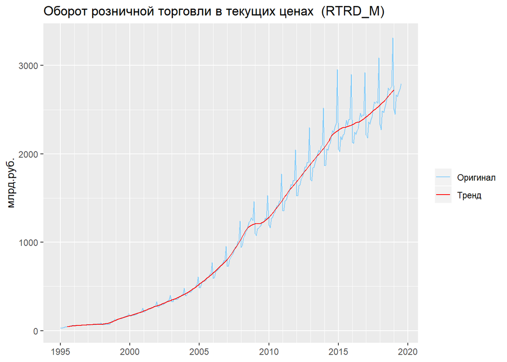

```r
autoplot(rtrd, series = 'Оригинал') +
  autolayer(trendcycle(rtrd_d), series = 'Тренд') +
  labs(color = NULL, x = NULL,
       y = rtrd_unit, title = rtrd_label) +
  scale_color_manual(values = c('lightskyblue', 'red')) +
  scale_x_continuous(minor_breaks = start(rtrd):end(rtrd))
```

Обратим внимание на то, что линия тренда короче исходного ряда. Это вызвано тем, что функция `decompose()` использует для выделения тренда скользящее среднее с окном, равным частоте временного ряда (12). В результате, по 6 периодов в начале и в конце ряда теряются, т.к. скользящее окно усреднения выходит в эти периоды за пределы данных и среднее не может быть вычислено.

На графике виден спад во время кризисов 2008 и 2015 года.

**Сезонный компонент**

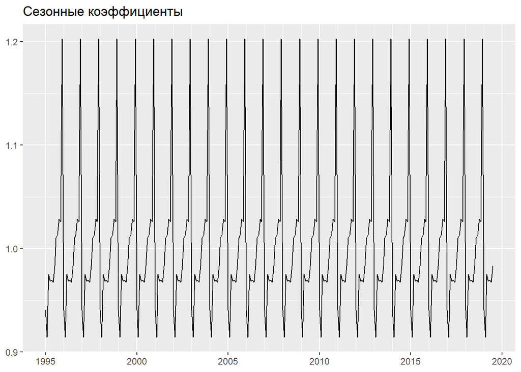

```r
autoplot(seasonal(rtrd_d)) +
  labs(y = NULL, x = NULL,
       title = 'Сезонные коэффициенты') +
  scale_x_continuous(minor_breaks = start(rtrd):end(rtrd))
```

В методе классической декомпозиции сезонные коэффициенты получаются с помощью усреднения наблюдений для одноименных месяцев после удаления тренда, поэтому наборы сезонных коэффициентов для всех лет одинаковы.

**Модель ряда**

Модель ряда получается путем сочетания выделенных закономерных компонентов. Сравним результат с исходными данными.

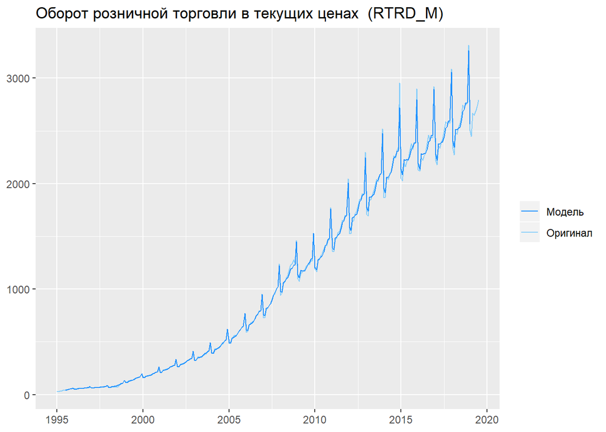

```r
autoplot(rtrd, series = 'Оригинал') +
  autolayer(trendcycle(rtrd_d) * seasonal(rtrd_d),
            series = 'Модель') +
  scale_colour_manual(values = c('dodgerblue', 'lightskyblue')) +
  labs(y = NULL, color = NULL, x = NULL,
       title = rtrd_label)
```

Результат близок к оригиналу, однако виды расхождения. Эти расхождения - **остатки**, или ошибки модели. Их также называют нерегулярным (случайным) компонентом ряда.

**Остатки**

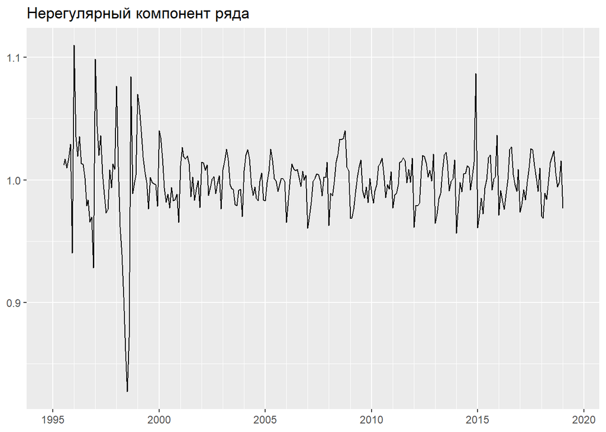

```r
autoplot(remainder(rtrd_d)) +
  labs(y = NULL, x = NULL,
       title = 'Нерегулярный компонент ряда') +
  scale_x_continuous(minor_breaks = start(rtrd):end(rtrd))
```

Заметны регулярные колебания остатков, следовательно, закономерные компоненты исключены не полностью. Это - следствие того, что на протяжении выбранного для анализа периода величина сезонных коэффициентов менялась, но классическая декомпозиция не позволила этого учесть. Следовательно, необходимо использовать другой метод и/или сократить количество наблюдений временного ряда.

## Сезонная корректировка ряда

Сезонная корректировка ряда позволяет исключить влияние сезонных колебаний. Это облегчает анализ краткосрочных изменений ряда, которые иначе не видны из-за сезонности. Для выполнения сезонной корректировки в R можно использовать функцию `forecast::seasadj()`. Эта функция принимает в качестве аргумента объект, созданный одной из функций для декомпозиции.

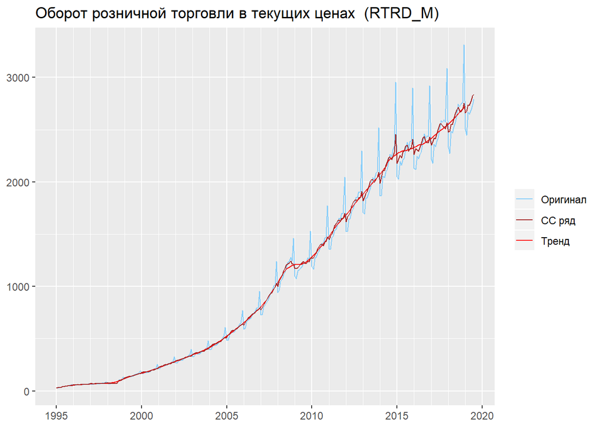

```r
rtrd_adj <- seasadj(rtrd_d)


autoplot(rtrd, series = 'Оригинал') +
  autolayer(trendcycle(rtrd_d), series = 'Тренд') +
  autolayer(rtrd_adj, series = 'СС ряд') +
  scale_colour_manual(values = c('lightskyblue', 'brown', 'red')) +
  labs(y = NULL, color = NULL, x = NULL,
       title = rtrd_label) +
  scale_x_continuous(minor_breaks = start(rtrd):end(rtrd))
```

В отличие от сильно сглаженной линии тренда, график сезонно-скорректированный ряд содержит случайные колебания уровня. Наш ряд имеет мультипликативную структуру, поэтому его модель может быть описана формулой:

$$y = T \cdot S \cdot E,$$

где $T$ - тренд, $S$ - сезонный коэффициент, $E$ - случайная (нерегулярная) составляющая, или ошибка, $y$ - наблюдаемое значение ряда.

Тренд - это только компонент $T$, а ряд с исключенной сезонностью получается с помощью деления:

$$A = \frac{y}{S} = T \cdot E.$$

В отличие от тренда, временной ряд с удаленной сезонностью содержит случайную составляющую $E$.

Аналогичного результата можно добиться и с помощью непосредственного деления исходного ряда на сезонные коэффициенты:

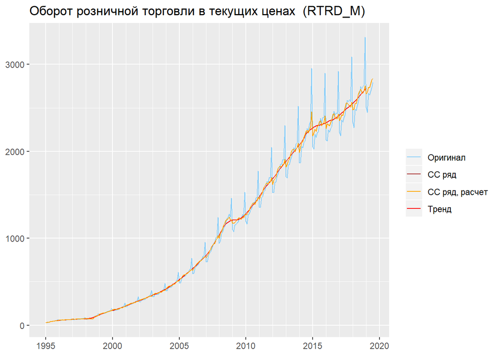

```r
autoplot(rtrd, series = 'Оригинал') +
  autolayer(trendcycle(rtrd_d), series = 'Тренд') +
  autolayer(rtrd_adj, series = 'СС ряд') +
  autolayer(rtrd/seasonal(rtrd_d), series = 'СС ряд, расчет') +
  scale_colour_manual(values = c('lightskyblue', 'brown', 'orange', 'red')) +
  labs(y = NULL, color = NULL, x = NULL,
       title = rtrd_label) +
  scale_x_continuous(minor_breaks = start(rtrd):end(rtrd))
```

Ряд с исключенной сезонностью содержит значения во всех периодах, т.к. для его вычисления используются непосредственно значения исходного ряда и сезонные коэффициенты. Сезонные коэффициенты - одни и те же для всех лет временного ряда, поэтому пустых периодов данных нет.

## Исключение тренда

Подобным же образом, можно удалить из ряда тренд, чтобы облегчить анализ изменений сезонного цикла.

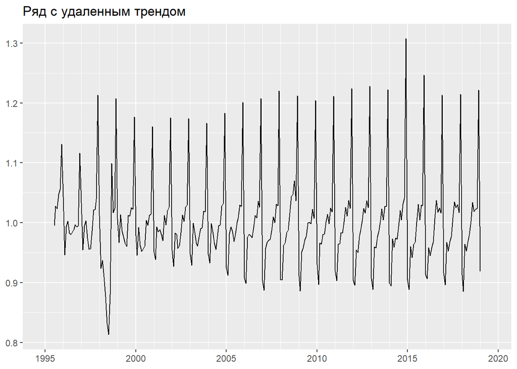

```r
rtrd_detrended <- rtrd/trendcycle(rtrd_d)

autoplot(rtrd_detrended) +
  labs(y = NULL, color = NULL, x = NULL,
       title = 'Ряд с удаленным трендом') +
  scale_x_continuous(minor_breaks = start(rtrd):end(rtrd))
```

В пакете `forecast` имеется функция для визуализации отличий сезонных колебаний в разные годы - `ggseasonplot()`. В зависимости от задачи, более наглядным может оказаться применение этой функции к ряду с удаленным трендом.

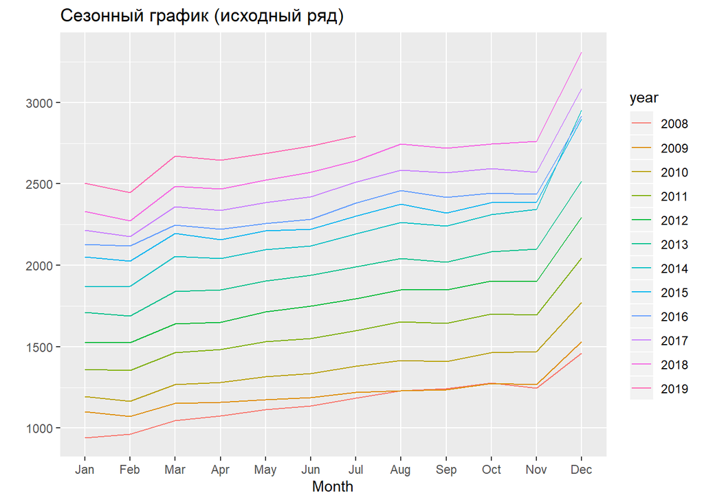

```r
# Исходный ряд
rtrd %>%
  window(start = 2008) %>%
  ggseasonplot() +
  labs(title = 'Сезонный график (исходный ряд)')
```

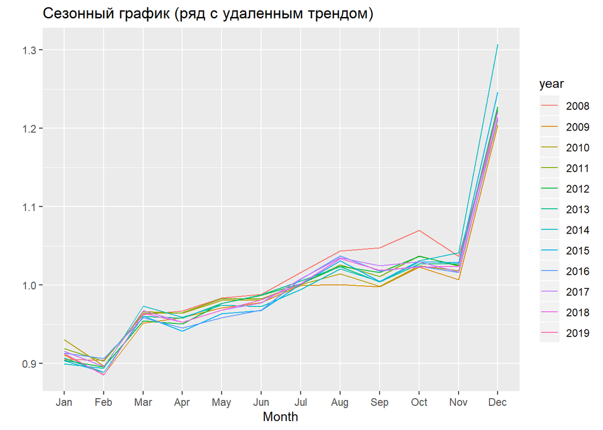

```r
# Ряд с удаленным трендом
rtrd_detrended %>%
  window(start = 2008) %>%
  ggseasonplot() +
  labs(title = 'Сезонный график (ряд с удаленным трендом)')
```

## STL-декомпозиция

Теперь выполним декомпозицию, используя функцию `forecast::stl()` (*Seasonal and Trend decomposition using Loess*). Данная функция также выделяет тренд с помощью сглаживания, но использует вместо скользящего среднего метод локальной регрессии - LOESS. Это позволяет исключить потерю данных на концах ряда. Кроме того, метод более устойчив к выбросам в данных ряда.

Недостатком этого подхода является поддержка сезонности только аддитивного типа. Большинство экономических временных рядов - мультипликативные.

Для решения этой проблемы можно либо разрешить сезонным компонентам ряда постепенно меняться (используя параметр `s.window` функции `stl()`), либо преобразовать данные, чтобы превратить мультипликативный характер сезонности в аддитивный.

### Изменяющиеся сезонные коэффициенты

Обязательный параметр `s.window` функции `stl()` задает ширину окна для сглаживания ряда методом LOESS при извлечении сезонного компонента. Значение параметра должно быть нечетным и не менее 7. Также можно задать `s.window = 'periodic'`, тогда набор сезонных коэффициентов будет одним и тем же для всех лет.

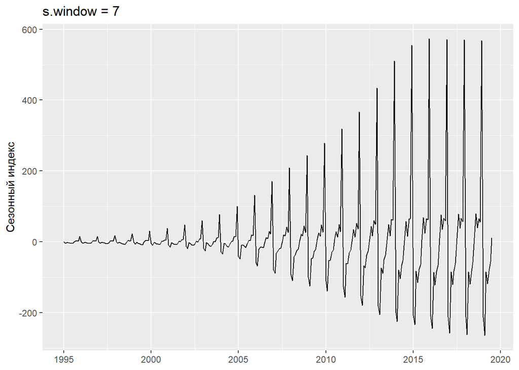

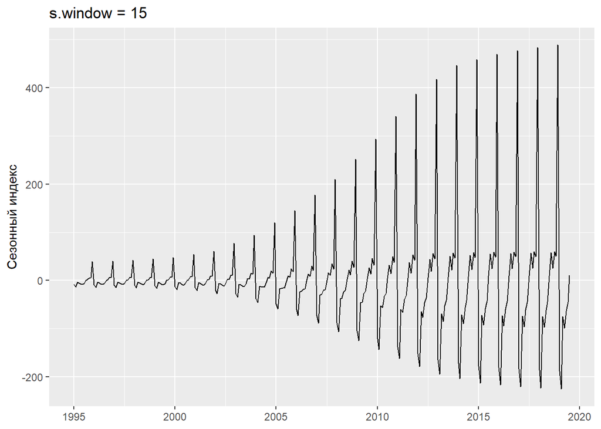

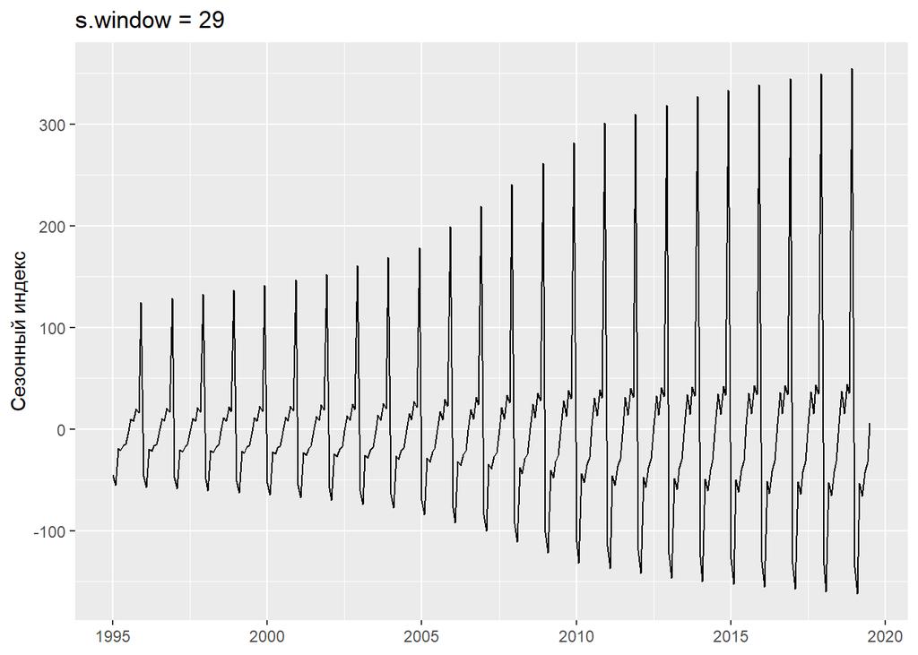

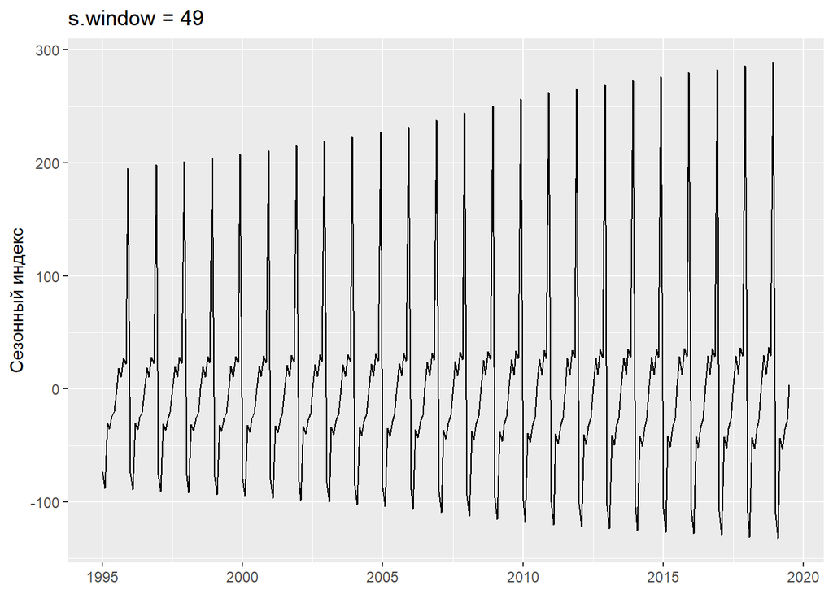

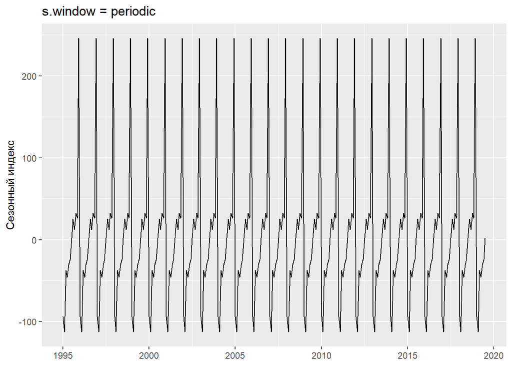

```r
# Ширина окна сглаживания w задается в цикле
for (w in list(7, 15, 29, 49, 'periodic')) {
  p <- autoplot(seasonal(stl(rtrd, s.window = w))) +
    labs(title = str_c('s.window = ', w),
         x = NULL, y = 'Сезонный индекс')
  print(p)
}
```

Увеличение ширины окна сглаживания снижает скорость изменения сезонного компонента, однако это приводит к появлению сезонных колебаний в остатках модели.

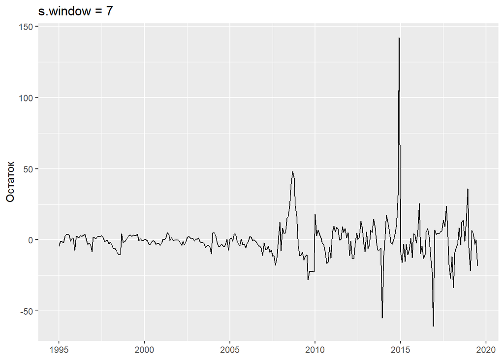

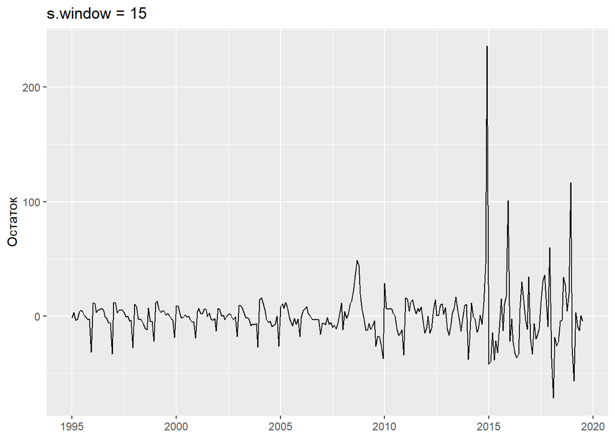

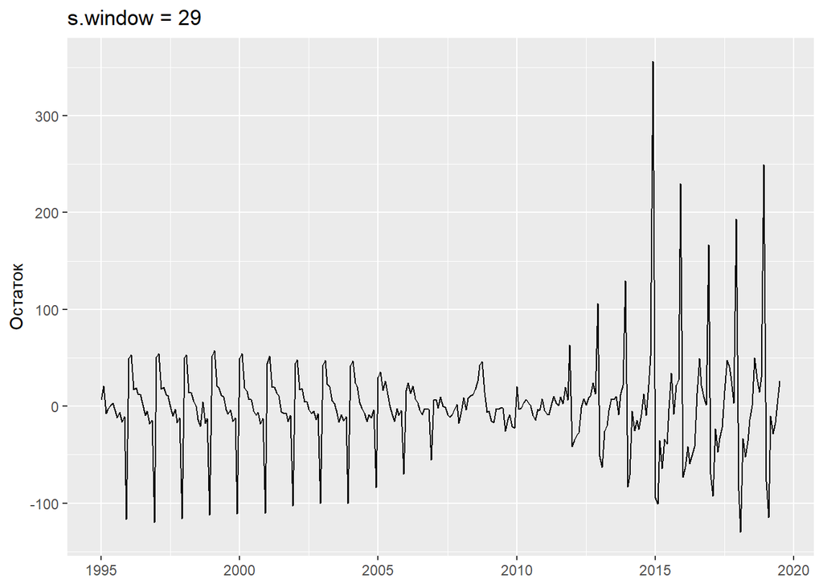

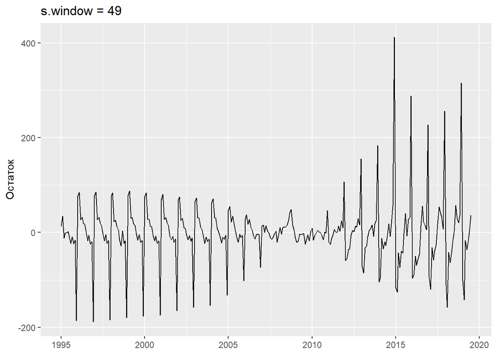

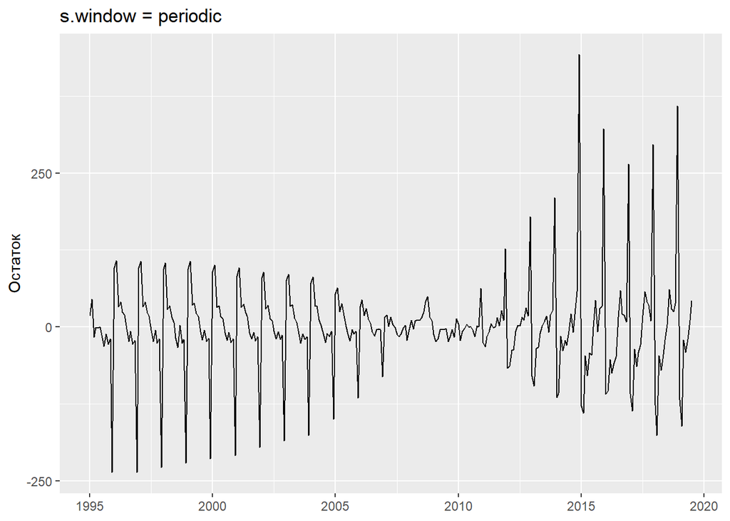

```r
# Ширина окна сглаживания w задается в цикле
for (w in list(7, 15, 29, 49, 'periodic')) {
  p <- autoplot(remainder(stl(rtrd, s.window = w))) +
    labs(title = str_c('s.window = ', w),
         x = NULL, y = 'Остаток')
  print(p)
}
```

В данном случае ряд изменяется очень быстро, поэтому выберем минимальную ширину окна для сглаживания сезонных индексов - 7.

```r
rtrd_stl <- stl(rtrd, s.window = 7)
```

Как и в случае с классической декомпозицией, отдельные компоненты ряда можно извлечь при помощи функций `seasonal()`, `trendcycle()` и `remainder()`.

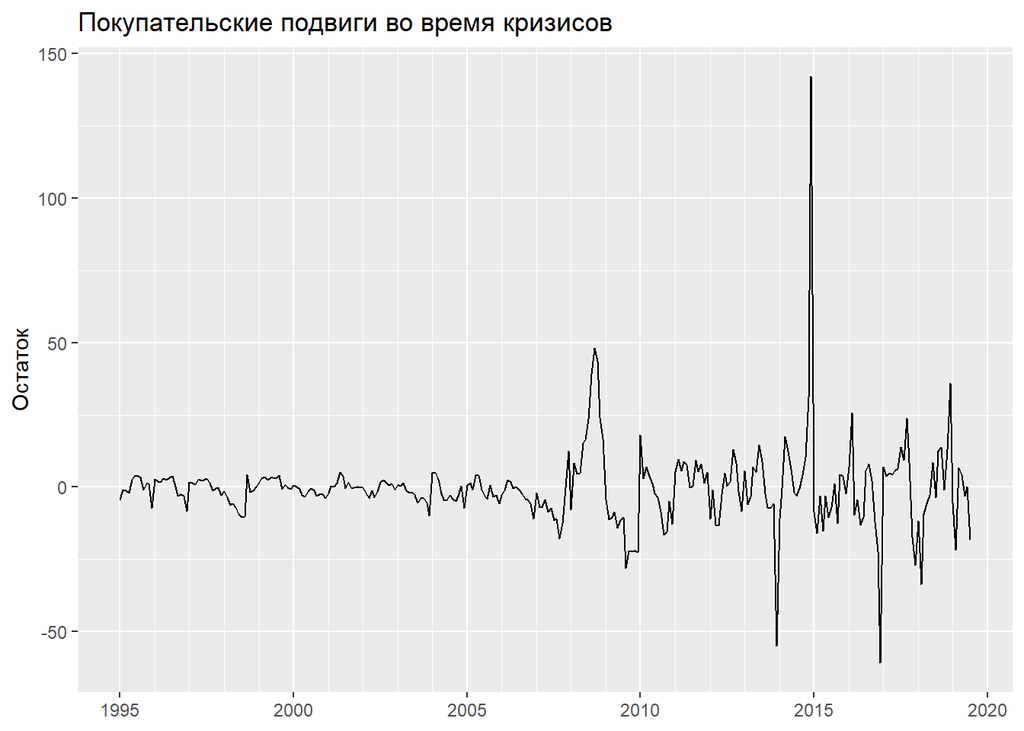

```r
rtrd_stl %>%
  remainder() %>%
  autoplot() +
    labs(title = 'Покупательские подвиги во время кризисов',
         x = NULL, y = 'Остаток') +
    scale_x_continuous(minor_breaks = start(rtrd):end(rtrd))
```

Сезонная корректировка ряда позволяет увидеть эти пики в масштабе исходных данных.

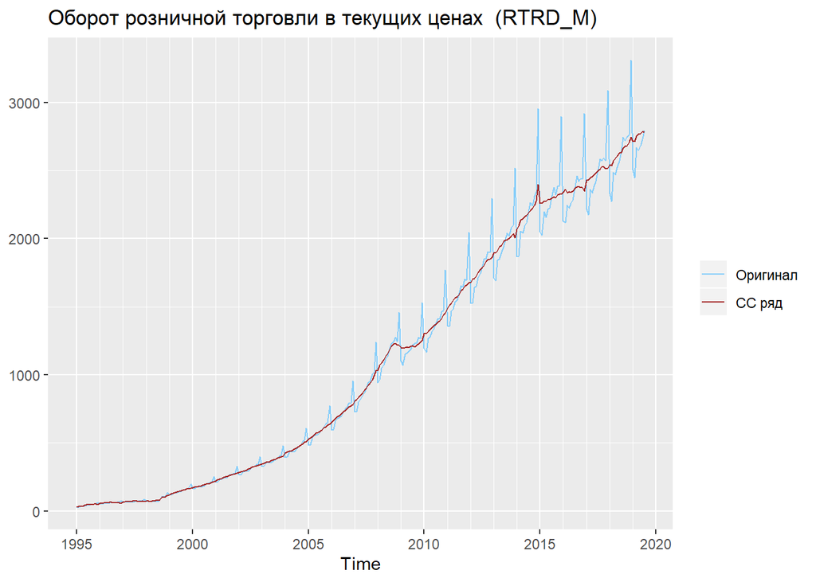

```r
autoplot(rtrd, series = 'Оригинал') +
  autolayer(seasadj(rtrd_stl), series = 'СС ряд') +
  scale_colour_manual(values = c('lightskyblue', 'brown')) +
  labs(y = NULL, title = rtrd_label, color = NULL) +
  scale_x_continuous(minor_breaks = start(rtrd):end(rtrd))
```

### Логарифмирование

Другой способ обойти проблему мультипликативной сезонности - преобразование данных. При логарифмировании произведение компонент ряда заменяется на сумму логарифмов:

$$y = T \cdot S \cdot E \Rightarrow \log y = \log T + \log S + \log E$$

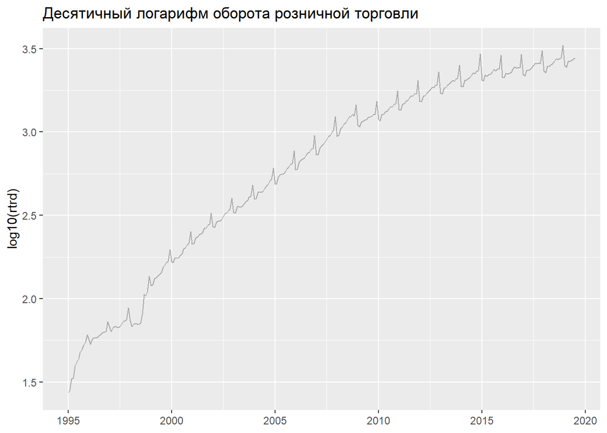

```r
autoplot(log10(rtrd)) +
  labs(title = 'Десятичный логарифм оборота розничной торговли',
       x = NULL) +
  geom_line(color = 'darkgray')
```

Аддитивная лучше подходит к преобразованным данным.

Данный подход неудобен тем, что для визуализации компонентов в исходном масштабе необходимо обратное преобразование - вычисление показательной функции. Также этот метод не применим, когда в исходных данных содержатся нули.

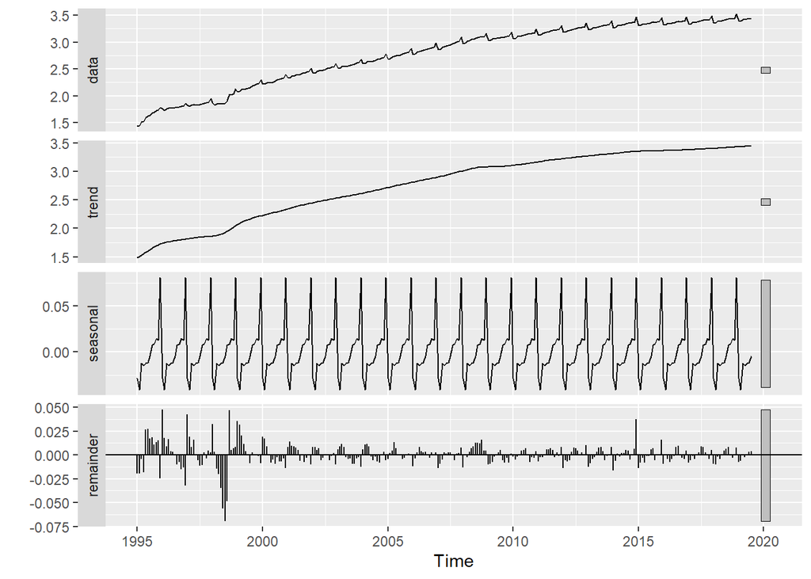

```r
log_rtrd_stl <- rtrd %>%
  log10() %>%
  stl(s.window = 'periodic')

autoplot(log_rtrd_stl)
```

Чтобы сравнить модель ряда с исходными данными, необходимо выполнить обратное преобразование компонентов ряда - $10^x$.

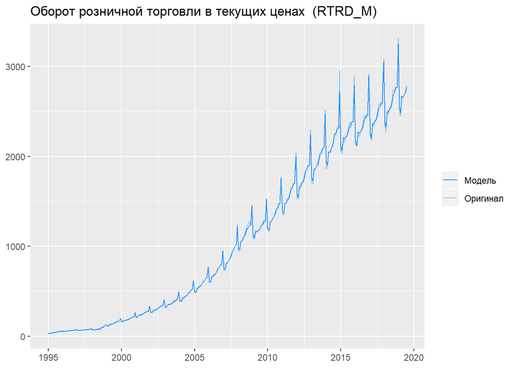

```r
rtrd_stl_fit <- 10^(trendcycle(log_rtrd_stl) +
                    seasonal(log_rtrd_stl))

autoplot(rtrd, series = 'Оригинал') +
  autolayer(rtrd_stl_fit, series = 'Модель') +
  scale_colour_manual(values = c('dodgerblue', 'lightskyblue')) +
  labs(y = NULL, color = NULL, x = NULL,
       title = rtrd_label)
```